# M5 Forecasting Uncertainty

#### By Weekday

The weekend days (Saturday and Sunday) see the highest volume. Monday through Friday are all vaguely similar in mean and variance.

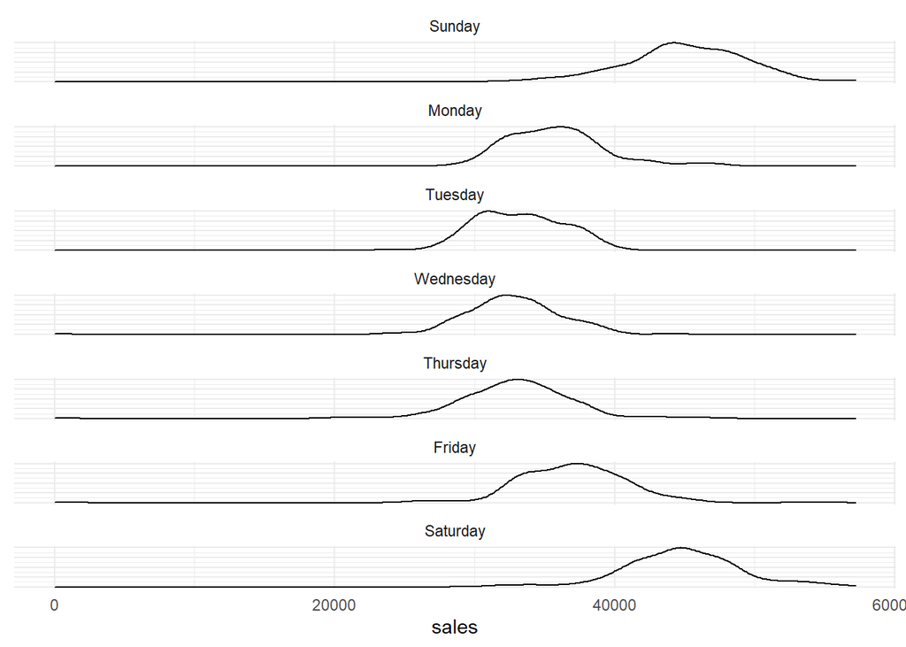

```r
data %>%
    group_by(
        wm_yr_wk, weekday_ordered
    ) %>%
    summarise(
        sales = sum(sales)
    ) %>%
    ungroup() %>%
    ggplot() +
        geom_density(aes(sales, ..scaled..)) +
        facet_wrap(~ weekday_ordered, ncol = 1) +
        theme_minimal() +
        theme(
            axis.text.y = element_blank(),
            axis.ticks.y = element_blank(),
            axis.title.y = element_blank()
        )
```

#### By Store

Daily sales by store are quite different, as we would expect.

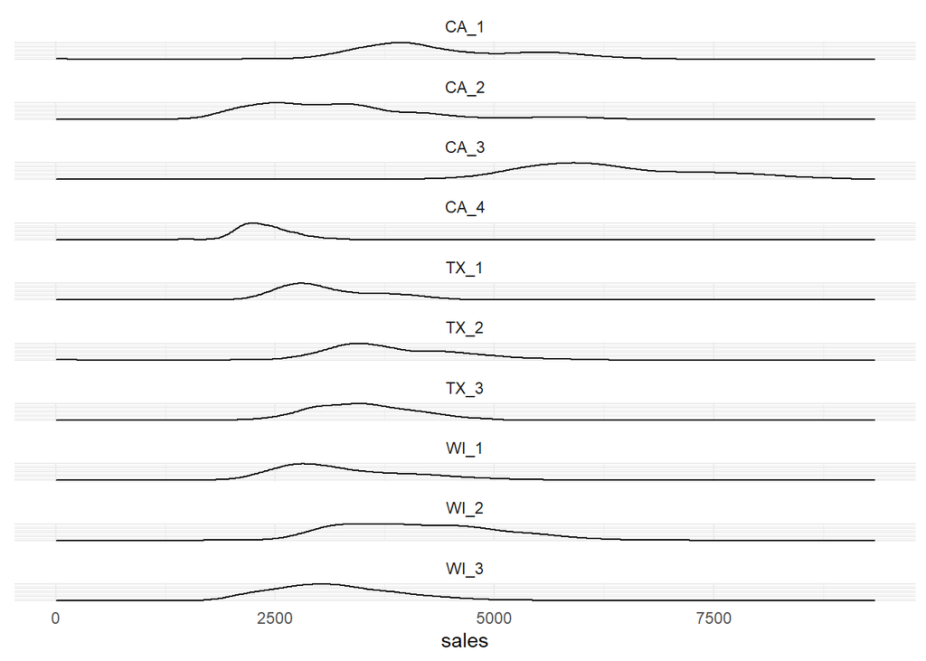

```r
data %>%
    group_by(
        date, store_id
    ) %>%
    summarise(
        sales = sum(sales)
    ) %>%
    ungroup() %>%
    ggplot() +
        geom_density(aes(sales, ..scaled..)) +
        facet_wrap(~ store_id, ncol = 1) +
        theme_minimal() +
        theme(
            axis.text.y = element_blank(),
            axis.ticks.y = element_blank(),
            axis.title.y = element_blank()
        )
```

#### By Month

In aggregate, monthly sales are extremely similar. This is most likely masking some significant differences in what items are being sold i.e. in Wisconsin, you may buy hiking gear in the summer, and approximately the same amount of snow gear in the winter.

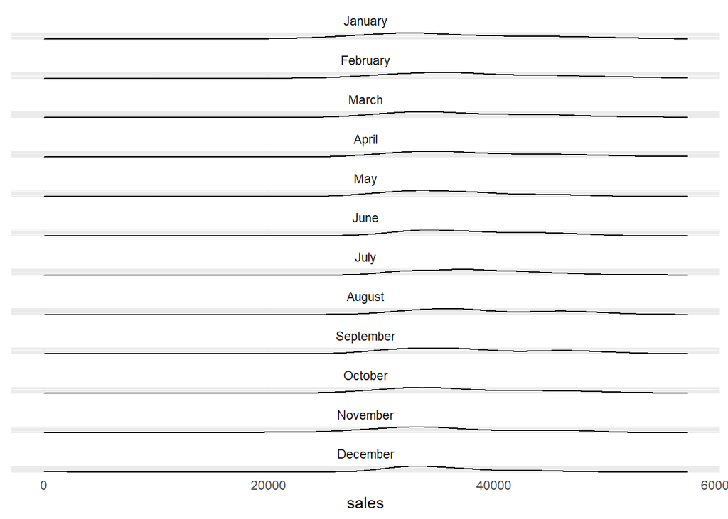

```r
data %>%
    group_by(
        date, month
    ) %>%
    summarise(
        sales = sum(sales)
    ) %>%
    ungroup() %>%
    ggplot() +
        geom_density(aes(sales, ..scaled..)) +
        facet_wrap(~ month, ncol = 1) +
        theme_minimal() +
        theme(
            axis.text.y = element_blank(),
            axis.ticks.y = element_blank(),
            axis.title.y = element_blank()
        )
```

### Correlation

#### By Department

We see high correlation by department with the notable exception of HOBBIES_2.

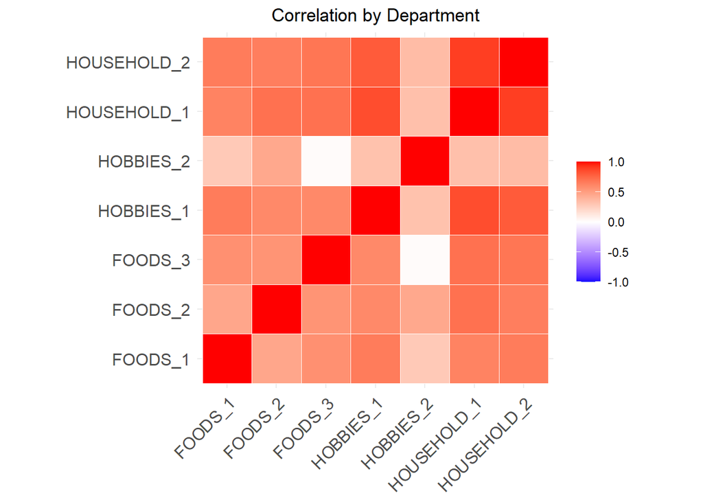

```r
data %>%
    group_by(date, dept_id) %>%
    summarise(
        sales = sum(sales)
    ) %>%
    pivot_wider(
        id_cols = date,
        names_from = dept_id,
        values_from = sales
    ) %>%
    ungroup() %>%
    select(- date) %>%
    as.data.frame() %>%
    cor(use = "pairwise.complete.obs") %>%
    ggcorrplot(
        legend.title = "",
        outline.color = "white"
    ) +
    theme(
        plot.title = element_text(hjust = 0.5)
    ) +
    labs(
        title = "Correlation by Department"
    )
```

#### By Weekday

The most prominent correlation is Saturday and Sunday sales. Nothing looks negative.

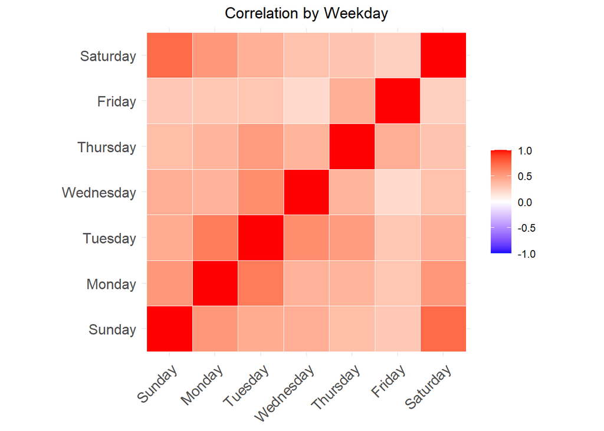

```r
data %>%
    group_by(wm_yr_wk, weekday_ordered) %>%
    summarise(
        sales = sum(sales)
    ) %>%
    pivot_wider(
        id_cols = wm_yr_wk,
        names_from = weekday_ordered,
        values_from = sales
    ) %>%
    ungroup() %>%
    select(- wm_yr_wk) %>%
    as.data.frame() %>%
    cor(use = "pairwise.complete.obs") %>%
    ggcorrplot(
        legend.title = "",
        outline.color = "white"
    ) +
    theme(
        plot.title = element_text(hjust = 0.5)
    ) +
    labs(
        title = "Correlation by Weekday"
    )
```

#### By Store

Stores appear to be highly correlated overall in total daily sales volume, which is interesting, and a bit different than what I would have guessed. Since this is an aggregate though, it still may mask some item level differences e.g. it’s way less likely that surf boards would sell well in Wisconsin, whereas they may sell well in a California summer.

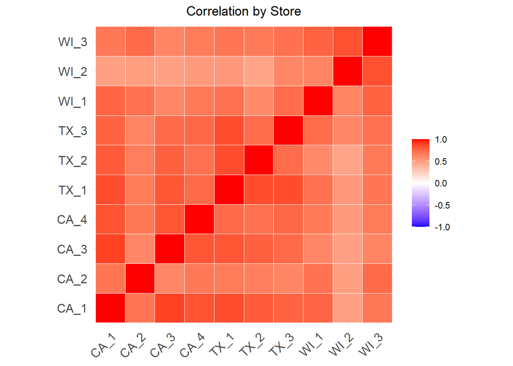

```r
data %>%
    group_by(date, store_id) %>%
    summarise(
        sales = sum(sales)
    ) %>%
    pivot_wider(
        id_cols = date,
        names_from = store_id,
        values_from = sales
    ) %>%
    ungroup() %>%
    select(- date) %>%
    as.data.frame() %>%
    cor(use = "pairwise.complete.obs") %>%
    ggcorrplot(
        legend.title = "",
        outline.color = "white"
    ) +
    theme(
        plot.title = element_text(hjust = 0.5)
    ) +
    labs(
        title = "Correlation by Store"
    )
```

#### By Month

We notice some key differences here, notably July and December are relatively uncorrelated in sales volume. July and December appear to be involved in most of the uncorrelated relationships.

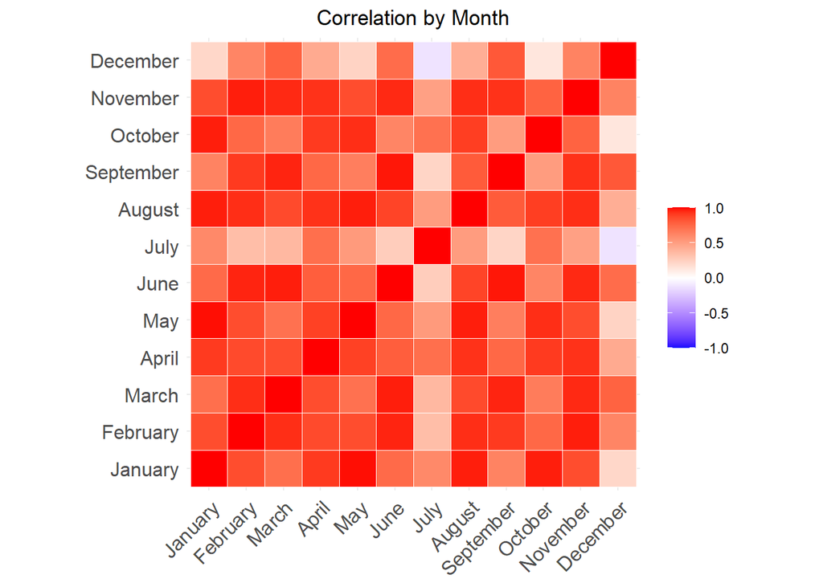

```r
data %>%
    group_by(weekday, month) %>%
    summarise(
        sales = sum(sales)
    ) %>%
    pivot_wider(
        id_cols = weekday,
        names_from = month,
        values_from = sales
    ) %>%
    ungroup() %>%
    select(- weekday) %>%
    as.data.frame() %>%
    cor(use = "pairwise.complete.obs") %>%
    ggcorrplot(
        legend.title = "",
        outline.color = "white"
    ) +
    theme(
        plot.title = element_text(hjust = 0.5)
    ) +
    labs(
        title = "Correlation by Month"
    )
```

### Timeseries

#### By Department

We see that the department FOODS_3 and HOUSEHOLD_1 sales appear more volatile than the other departments. Also, we see a huge dip in every department on the same day: Christmas Day.

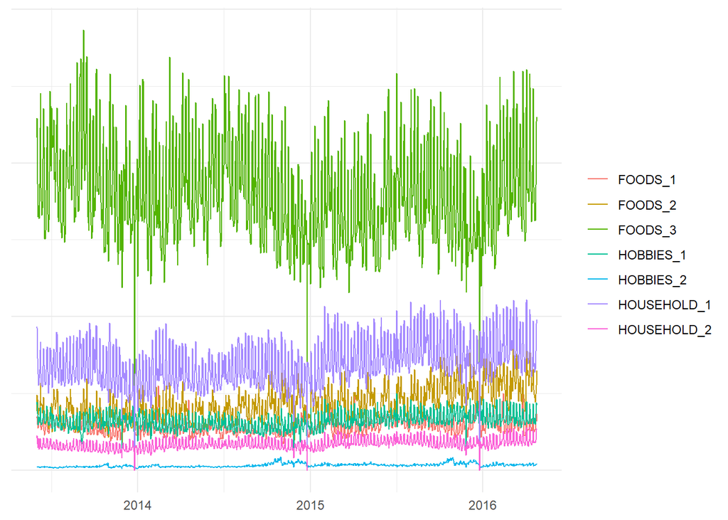

```r
data %>%
    group_by(date, dept_id) %>%
    summarise(
        sales = sum(sales)
    ) %>%
    ggplot(
        aes(date, sales, color = dept_id)
        ) +
        geom_line() +
        theme_minimal() +
        theme(
            axis.text.y = element_blank(),
            axis.ticks.y = element_blank(),
            axis.title.y = element_blank(),
            axis.title.x = element_blank(),
            legend.title = element_blank()
        )
```

#### By Weekday

Not much to see here. Note that the big dips are Christmas day.

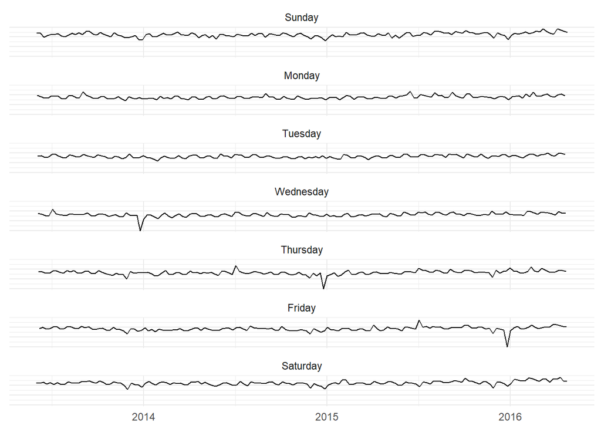

```r
data %>%
    group_by(date, weekday_ordered) %>%
    summarise(
        sales = sum(sales)
    ) %>%
    ggplot(
        aes(date, sales)
        ) +
        geom_line() +
        facet_wrap(~ weekday_ordered, ncol = 1) +
        theme_minimal() +
        theme(
            axis.text.y = element_blank(),
            axis.ticks.y = element_blank(),
            axis.title.y = element_blank(),
            axis.title.x = element_blank(),
            legend.title = element_blank()
        )
```

#### By Store

Stores may show some difference in sales, but nothing stands out too much. We’ll revisit store level differences later.

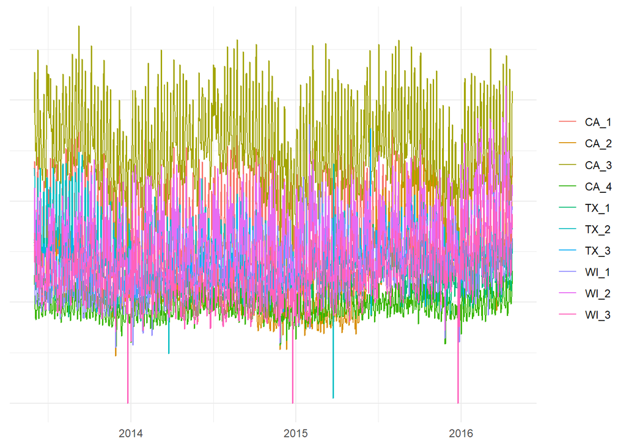

```r
data %>%
    group_by(date, store_id) %>%
    summarise(
        sales = sum(sales)
    ) %>%
    ggplot(
        aes(date, sales, color = store_id)
        ) +
        geom_line() +
        theme_minimal() +
        theme(
            axis.text.y = element_blank(),
            axis.ticks.y = element_blank(),
            axis.title.y = element_blank(),
            axis.title.x = element_blank(),
            legend.title = element_blank()
        )
```